# Introduction to R

### Demo: Saving Output

Conduct a t-test using iris data to see if petal lengths for setosa and versicolor are the same. The `t.test` function can only handle two groups, so subset out the virginica species.

```r
iris.subset <- iris[iris$Species != "virginica", ]
t.test(Petal.Length ~ Species, data = iris.subset)
##
##  Welch Two Sample t-test
##
## data:  Petal.Length by Species
## t = -39.493, df = 62.14, p-value < 2.2e-16
## alternative hypothesis: true difference in means is not equal to 0
## 95 percent confidence interval:
##  -2.939618 -2.656382
## sample estimates:
##     mean in group setosa mean in group versicolor
##                    1.462                    4.260
```

Save the output of the t-test to an object:

```r
tout <- t.test(Petal.Length ~ Species, data = iris.subset)
```

Look at the structure of the t-test object:

```r
str(tout)
## List of 9
##  $ statistic  : Named num -39.5
##   ..- attr(*, "names")= chr "t"
##  $ parameter  : Named num 62.1
##   ..- attr(*, "names")= chr "df"
##  $ p.value    : num 9.93e-46
##  $ conf.int   : atomic [1:2] -2.94 -2.66
##   ..- attr(*, "conf.level")= num 0.95
##  $ estimate   : Named num [1:2] 1.46 4.26
##   ..- attr(*, "names")= chr [1:2] "mean in group setosa" "mean in group versicolor"
##  $ null.value : Named num 0
##   ..- attr(*, "names")= chr "difference in means"
##  $ alternative: chr "two.sided"
##  $ method     : chr "Welch Two Sample t-test"
##  $ data.name  : chr "Petal.Length by Species"
##  - attr(*, "class")= chr "htest"
```

Since this is simply a list, use regular indexing to access the p-value.

```r
tout$p.value
## [1] 9.934433e-46
tout[[3]]
## [1] 9.934433e-46
```

## Importing Data

It is generally necessary to import data in to R rather than just using built-in datasets.

- Tell R where the data is saved using `setwd()` (or an appropriate file path)
- Read in data using R functions such as:
  - `read.table()` for reading in .txt files
  - `read.csv()` for reading in .csv files
  - the `readr` package has “smarter” versions of these functions and may be more useful
- Assign the data to new R object when reading in the file

### Importing Data Demo

First, create a csv file. Use a text editor, excel… Then load it in:

```r
littledata <- read.csv("PretendData.csv")
```

##### Your Turn

- Make 5 rows of data in an excel spreadsheet and save it as a *tab-delimited txt file*.
- Import this new .txt file into R with `read.table`. You may need to look at the help page for `read.table` in order to properly do this.

##### Solutions

Excel Spreadsheet (also at https://bit.ly/2hOYYYT)

```r
webcomics <- read.table("./data/FunWebcomics.txt", header = T)
webcomics
##          Fun.Webcomics                                      URL
## 1                 xkcd                         http://xkcd.com/
## 2    sarah's scribbles http://www.gocomics.com/sarahs-scribbles
## 3          the oatmeal                   http://theoatmeal.com/
## 4      dinosaur comics                   http://www.qwantz.com/
## 5 hyperbole and a half   http://hyperboleandahalf.blogspot.com/
```

# Packages and Basic Programming

## R Packages

- Commonly used R functions are installed with base R
- R packages containing more specialized R functions can be installed freely from CRAN servers using function `install.packages()`
- After packages are installed, their functions can be loaded into the current R session using the function `library()`

### Finding R Packages

- How do I locate a package with the desired function?
- Google (“R project” + search term works well)
- R website task views to search relevent subjects: http://cran.r-project.org/web/views/
- ??searchterm will search R help for pages related to the search term
- `sos` package adds helpful features for searching for packages related to a particular topic

Handy R Packages:

- `ggplot2`: Statistical graphics
- `dplyr`/`tidyr`: Manipulating data structures
- `knitr`: integrate LaTeX, HTML, or Markdown with R for easy reproducible research

## Creating Functions

Code Skeleton:

```r
foo <- function(arg1, arg2, ...) {
    # Code goes here
    return(output)
}
```

Example:

```r
mymean <- function(data) {
    ans <- sum(data) / length(data)
    return(ans)
}
```

## If/Else Statements

Skeleton:

```r
if (condition) {
    # Some code that runs if condition is TRUE
} else {
    # Some code that runs if condition is FALSE
}
```

Example:

```r
mymean <- function(data) {
    if (!is.numeric(data)) {
        stop("Numeric input is required")
    } else {
        ans <- sum(data) / length(data)
        return(ans)
    }
}
```

## Looping

- Reduce the amount of typing
- Let R do repetitive tasks automatically
- R offers several loops: for, while, repeat.

```r
for (i in 1:3) {
    print(i)
}
## [1] 1
## [1] 2
## [1] 3
```

### For Loops

```r
tips <- read.csv("https://bit.ly/2iNqvKM")

id <- c("total_bill", "tip", "size")
for (colname in id) {
    print(colname)
}
## [1] "total_bill"
## [1] "tip"
## [1] "size"

for(colname in id) {
    print(paste(colname, mymean(tips[, colname])))
}
## [1] "total_bill 19.7859426229508"
## [1] "tip 2.99827868852459"
## [1] "size 2.56967213114754"
```

### While Loops

```r
i <- 1
while (i <= 5) {
    print(i)
    i <- i + 1
}
## [1] 1
## [1] 2
## [1] 3
## [1] 4
## [1] 5
```

##### Your Turn

1. Create a function that takes numeric input and provides the mean and standard deviation for the data (`sd` may be useful)
2. Add checks to your function to make sure the data is either numeric or logical. If it is logical convert it to numeric.
3. Loop over the columns of the diamonds data set and apply your function to all of the numeric columns.

##### Solutions

1. Create a function that takes numeric input and provides the mean and standard deviation for the data (`sd` may be useful)

```r
myfun <- function(x) {
  m <- mean(x)
  s <- sd(x)
  return(c(mean = m, sd = s))
}
```

2. Add checks to your function to make sure the data is either numeric or logical. If it is logical convert it to numeric.

```r
myfun <- function(x) {
  if (is.logical(x)) {
    x <- as.numeric(x)
  }
  if (!is.numeric(x)) {
    warning("x is not logical or numeric. Cannot compute a mean or std. deviation.")
    return(c(mean = NA, sd = NA))
  }
  m <- mean(x)
  s <- sd(x)
  return(c(mean = m, sd = s))
}
```

3. Loop over the columns of the diamonds data set and apply your function to all of the numeric columns.

```r
data(diamonds)
diamondStats <- matrix(0, nrow = ncol(diamonds), ncol = 2,
                       dimnames = list(names(diamonds),
                                       c("mean", "sd")))

for(i in 1:ncol(diamonds)) {
  diamondStats[i,] <- myfun(diamonds[[i]])
}

diamondStats
##                 mean           sd
## carat      0.7979397    0.4740112
## cut               NA           NA
## color             NA           NA
## clarity           NA           NA
## depth     61.7494049    1.4326213
## table     57.4571839    2.2344906
## price   3932.7997219 3989.4397381
## x          5.7311572    1.1217607
## y          5.7345260    1.1421347
## z          3.5387338    0.7056988
```

# R Markdown Basics

## Hello R Markdown!

[figure not shown]

Choose your output format!

[figure not shown]

### *Why* R Markdown?

- It’s **simple**. Focus on writing, rather than copy/paste and formatting
- It’s **flexible**. Markdown was created to simplify writing HTML, but thanks to [pandoc](http://pandoc.org/), Markdown converts to many different formats!
- It’s **dynamic**. Find a critical error? Get a new dataset? Regenerate a report without copy/paste problems!
  - Automating reports made easy!
- Encourages **transparency**. Collaborators (including future you) will appreciate having the analysis & report integrated.
- Enables **interactivity/reactivity**. Allow your audience to explore the analysis (rather than passively read it).

### *What* is Markdown?

- Markdown is a particular type of markup language.
- Markup languages are designed to produce documents from plain text.
- Some of you may be familiar with *LaTeX*. This is another (less human friendly) markup language for creating pdf documents.
- *LaTeX* gives greater control, but it is restricted to pdf and has a **much** steeper learning curve.
- Markdown is becoming a standard. Many websites will generate HTML from Markdown (e.g. GitHub, Stack Overflow, reddit).

### *Who* is using R Markdown, and *for what*?

- The [R Markdown website](http://rmarkdown.rstudio.com/) is built with R Markdown.
- The [new edition of the ggplot2 book](https://github.com/hadley/ggplot2-book/) uses it.
- R package vignettes (for example, [a vignette for plotly](http://cpsievert.github.io/plotly/pipe-dsl/)).
- [Many](http://lincolnmullen.com/projects/dh-r/index.html) great [tutorials](http://renkun.me/learnR/) use R markdown add-ons such as [Rgitbook](http://jason.bryer.org/Rgitbook/).
- People are [blogging with it](http://cpsievert.github.io/knitr-jekyll//2015/04/jekyll-tufte-servr.html).
- This course is built with markdown

## *R* Markdown

- Straight from the [R Markdown home page](http://rmarkdown.rstudio.com/):

> R Markdown is an authoring format that enables easy creation of dynamic documents, presentations, and reports from R. It combines the core syntax of **markdown** (an easy-to-write plain text format) **with embedded R code chunks** that are run so their output can be included in the final document. R Markdown documents are fully reproducible (they can be automatically regenerated whenever underlying R code or data changes).

##### Your Turn

Study the first page of the [R Markdown Reference Guide](https://www.rstudio.com/wp-content/uploads/2015/03/rmarkdown-reference.pdf).

Yes, the *entire* markdown syntax can be described in one page!

Can you think of anything that is missing from the syntax (that you might want when creating documents)?

## RMarkdown details

Markdown doesn’t natively support…

- Stuff in formal publications:
  - Figure/table referencing  
    (there are addins for this functionality)
  - Picture resizing (for word docs)
- Many, many appearance related things
  - image/figure alignment
  - coloring
  - fonts

There is hope…

- Complex formatting using HTML/`LaTeX` markup, but don’t expect it to convert between output formats.
- There are many efforts to extend Markdown  
  (but, then again, keeping it simple is the point!)
- More features are being added daily
- Create or use templates for better control over formatting

##### Your Turn

Have a look at R Markdown presentations and templates.

[figure not shown]

**Pro tip**: run `devtools::install_github("rstudio/rticles")` to get more templates

### Format Options

The stuff at the top of the .Rmd file (called *yaml front matter*) tells **rmarkdown** what output format you want.

```
---
title: "Untitled"
date: "May 16, 2016"
output: html_document
---
```

In this case, when “Knit HTML” is clicked, RStudio calls `rmarkdown::render("file.Rmd", html_document())`. Default values can be changed (see the [source of this presentation](https://raw.githubusercontent.com/srvanderplas/NPPD-Analytics-Workshop/master/01.Introduction/01.slides.Rmd)).

## Code Chunks

A code chunk is a concept borrowed from the [knitr](http://yihui.name/knitr/) package (which, in turn, was inspired by [literate programming](http://en.wikipedia.org/wiki/Literate_programming)). In .Rmd files, start/end a code chunk with three back-ticks.

````
```{r chunk1}
1 + 1
```
````

Want to run a command in another language?

````
```{r chunk2, engine = 'python'}
print "a" + "b"
```
````

### Options

There are a plethora of [chunk options](http://yihui.name/knitr/options/) in **knitr** (engine is one of them). Here are some that I typically use:

- `echo`: Show the code?
- `eval`: Run the code?
- `message`: Relay messages?
- `warning`: Relay warnings?
- `fig.width` and `fig.height`: Change size of figure output.
- `cache`: Save the output of this chunk (so we don’t have to run it next time)?

##### Your Turn

Study the second page of the [R Markdown Reference Guide](https://www.rstudio.com/wp-content/uploads/2015/03/rmarkdown-reference.pdf) and go back to the Hello R Markdown example we created.

- **Easy**: Modify the figure sizing and alignment.
- **Medium**: Add a figure caption.
- **Hard**: Can you create an animation? (Hint: look at the `fig.show` chunk option – you might need to the **animation** package for this)

**Pro Tip**: Don’t like the default chunk option value? Change it at the top of the document:

````
```{r setup2, verbatim = TRUE}
knitr::opts_chunk$set(message = FALSE, warning = FALSE)
```
````

##### Solutions

````
```{r, fig.align = "right", fig.width = 3, fig.height = 3, out.width = "50%"}
qplot(rnorm(100))
```
````

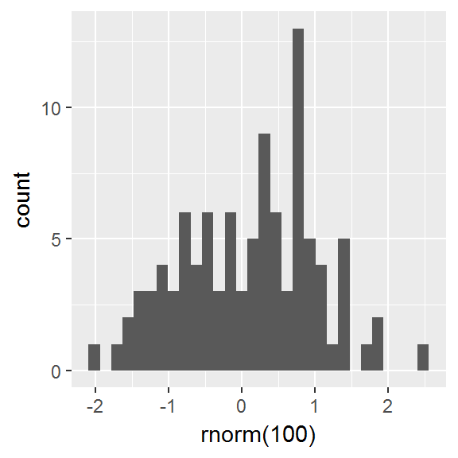

````
```{r, fig.cap = "Histogram of 100 samples from a normal distribution"}
qplot(rnorm(100))
```
````

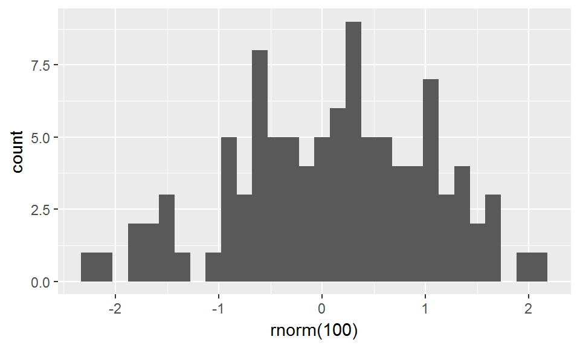

Histogram of 100 samples from a normal distribution

````
```{r, fig.show = 'animate', ffmpeg.format = 'mp4'}
samples <- seq(100, 500, 50)
for (i in samples) {
  print(
    qplot(rnorm(i)) + ggtitle(sprintf("%d Samples from a Normal Dist", i))
  )
}
```
````

[video not shown]

## Formatting R output

Ugly:

```r
m <- lm(mpg ~ disp, data = mtcars)
summary(m) # output isn't very attractive
##
## Call:
## lm(formula = mpg ~ disp, data = mtcars)
##
## Residuals:
##     Min      1Q  Median      3Q     Max
## -4.8922 -2.2022 -0.9631  1.6272  7.2305
##
## Coefficients:
##              Estimate Std. Error t value Pr(>|t|)
## (Intercept) 29.599855   1.229720  24.070  < 2e-16 ***
## disp        -0.041215   0.004712  -8.747 9.38e-10 ***
## ---
## Signif. codes:  0 '***' 0.001 '**' 0.01 '*' 0.05 '.' 0.1 ' ' 1
##
## Residual standard error: 3.251 on 30 degrees of freedom
## Multiple R-squared:  0.7183, Adjusted R-squared:  0.709
## F-statistic: 76.51 on 1 and 30 DF,  p-value: 9.38e-10
```

Pretty:  
[pander](http://rapporter.github.io/pander/) is one great option.

```r
library(pander)
pander(m)
```

Fitting linear model: mpg ~ disp

|  | Estimate | Std. Error | t value | Pr(>\|t\|) |
| --- | --- | --- | --- | --- |
| **disp** | -0.04122 | 0.004712 | -8.747 | 9.38e-10 |
| **(Intercept)** | 29.6 | 1.23 | 24.07 | 3.577e-21 |

Ugly:

```r
a <- anova(m)
a
## Analysis of Variance Table
##
## Response: mpg
##           Df Sum Sq Mean Sq F value   Pr(>F)
## disp       1 808.89  808.89  76.513 9.38e-10 ***
## Residuals 30 317.16   10.57
## ---
## Signif. codes:  0 '***' 0.001 '**' 0.01 '*' 0.05 '.' 0.1 ' ' 1
```

Pretty:

```r
pander(a)
```

Analysis of Variance Table

|  | Df | Sum Sq | Mean Sq | F value | Pr(>F) |
| --- | --- | --- | --- | --- | --- |
| **disp** | 1 | 808.9 | 808.9 | 76.51 | 9.38e-10 |
| **Residuals** | 30 | 317.2 | 10.57 | NA | NA |

### Pander knows about a lot of stuff!

```r
methods(pander)
##  [1] pander.anova*           pander.aov*
##  [3] pander.aovlist*         pander.Arima*
##  [5] pander.call*            pander.cast_df*
##  [7] pander.character*       pander.clogit*
##  [9] pander.coxph*           pander.cph*
## [11] pander.CrossTable*      pander.data.frame*
## [13] pander.Date*            pander.default*
## [15] pander.density*         pander.describe*
## [17] pander.evals*           pander.factor*
## [19] pander.formula*         pander.ftable*
## [21] pander.function*        pander.glm*
## [23] pander.Glm*             pander.gtable*
## [25] pander.htest*           pander.image*
## [27] pander.irts*            pander.list*
## [29] pander.lm*              pander.lme*
## [31] pander.logical*         pander.lrm*
## [33] pander.manova*          pander.matrix*
## [35] pander.microbenchmark*  pander.mtable*
## [37] pander.name*            pander.nls*
## [39] pander.NULL*            pander.numeric*
## [41] pander.ols*             pander.orm*
## [43] pander.polr*            pander.POSIXct*
## [45] pander.POSIXlt*         pander.prcomp*
## [47] pander.randomForest*    pander.rapport*
## [49] pander.rlm*             pander.sessionInfo*
## [51] pander.smooth.spline*   pander.stat.table*
## [53] pander.summary.aov*     pander.summary.aovlist*
## [55] pander.summary.glm*     pander.summary.lm*
## [57] pander.summary.lme*     pander.summary.manova*
## [59] pander.summary.nls*     pander.summary.polr*
## [61] pander.summary.prcomp*  pander.summary.rms*
## [63] pander.summary.survreg* pander.summary.table*
## [65] pander.survdiff*        pander.survfit*
## [67] pander.survreg*         pander.table*
## [69] pander.tabular*         pander.ts*
## [71] pander.zoo*
## see '?methods' for accessing help and source code
```

##### Your Turn

- Look through the list of pander methods. Can you apply any of the methods that we haven’t discussed? We just saw `pander.lm` and `pander.anova`.